# **Music Recommendation System**

## **Problem Definition**

### **The Context:**

QUESTION:

- Why is this problem important to solve?

**ANSWER:** Recommended products on ecommerce website Amazon make up 35% of all purchases (SOURCE). Other companies such as Netflix and Spotify also rely on recommendation systems to predict which movies, series, and songs will appeal to their large user base. Highly precise recommendation systems can help increase sales for many businesses. If customers are happy with recommendations they tend to stay customers and consume more product.

### **The objective:**

QUESTION:

- What is the intended goal?

**ANSWER:** Over the course of this project, we will prepare song and user data and process it in such a way that we can make recommendations to customers. By the end of this notebook we will be able to recommend 10 songs to a user based on their music preferences and their similarity to other users on the platform.

### **The key questions:**

QUESTION:

- What are the key questions that need to be answered?

**ANSWER:** We shall determine which songs are similar and which users are similar. This will give us a basis for the final question, where we will answer what song should be played to the user next.

### **The problem formulation**:

QUESTION:

- What is it that we are trying to solve using data science?

**ANSWER:** We are ultimately trying to solve the boredom problem. Users rely on music to pass the time and enrich moments of relaxation, studying, or partying. By offering a valuable service to customers we can extract more subscription fees from subscribers and play more ads for free accounts. Recommendation systems are a vehicle for keeping users engaged and consuming our content, leading to higher profits for the streaming service company.

## **Data Dictionary**

The core data is the Taste Profile Subset released by the Echo Nest as part of the Million Song Dataset. There are two files in this dataset. The first file contains the details about the song id, titles, release, artist name, and the year of release. The second file contains the user id, song id, and the play count of users.

**song_data**

- song_id - A unique id given to every song
- title - Title of the song
- Release - Name of the released album
- Artist_name - Name of the artist
- year - Year of release

**count_data**

- user _id - A unique id given to the user
- song_id - A unique id given to the song
- play_count - Number of times the song was played

## **Data Source**

http://millionsongdataset.com/

## **Important Notes**

- This notebook can be considered a guide to refer to while solving the problem. The evaluation will be as per the Rubric shared for the Milestone. Unlike previous courses, it does not follow the pattern of the graded questions in different sections. This notebook would give you a direction on what steps need to be taken to get a feasible solution to the problem. Please note that this is just one way of doing this. **There can be other 'creative' ways to solve the problem, and we encourage you to feel free and explore them as an 'optional' exercise**.
- In the notebook, there are markdown cells called Observations and Insights. It is a good practice to provide observations and extract insights from the outputs.
- The naming convention for different variables can vary. **Please consider the code provided in this notebook as a sample code.**
- All the outputs in the notebook are just for reference and can be different if you follow a different approach.
- There are sections called **Think About It** in the notebook that will help you get a better understanding of the reasoning behind a particular technique/step. Interested learners can take alternative approaches if they want to explore different techniques.

### **Importing Libraries and the Dataset**

**Note**: After running this commands, you’ll be prompted to restart your notebook/runtime. Please go ahead and do that. Once restarted, simply proceed to the next step of your workflow

```python
!pip install numpy==1.26.0
```

[output not shown]

```python
# Mounting the drive
from google.colab import drive
drive.mount('/content/drive')
```

```python
# Used to ignore the warning given as output of the code
import warnings
warnings.filterwarnings('ignore')

# Basic libraries of python for numeric and dataframe computations
import numpy as np
import pandas as pd

# Basic library for data visualization
import matplotlib.pyplot as plt

# Slightly advanced library for data visualization
import seaborn as sns

# To compute the cosine similarity between two vectors
from sklearn.metrics.pairwise import cosine_similarity

# A dictionary output that does not raise a key error
from collections import defaultdict

# A performance metrics in sklearn
from sklearn.metrics import mean_squared_error
```

### **Load the dataset**

```python
#importing the datasets
count_df = pd.read_csv('/content/drive/MyDrive/MIT_AAIDSP_GL/Recommendation_Systems/Capstone_Music_Rec_Systems/count_data.csv')
song_df = pd.read_csv('/content/drive/MyDrive/MIT_AAIDSP_GL/Recommendation_Systems/Capstone_Music_Rec_Systems/song_data.csv')
```

### **Understanding the data by viewing a few observations**

```python
# Display the first 10 records of count_df
count_df.head(10)
```

|  | Unnamed: 0 | user_id | song_id | play_count |
| --- | --- | --- | --- | --- |
| 0 | 0 | b80344d063b5ccb3212f76538f3d9e43d87dca9e | SOAKIMP12A8C130995 | 1 |
| 1 | 1 | b80344d063b5ccb3212f76538f3d9e43d87dca9e | SOBBMDR12A8C13253B | 2 |
| 2 | 2 | b80344d063b5ccb3212f76538f3d9e43d87dca9e | SOBXHDL12A81C204C0 | 1 |
| 3 | 3 | b80344d063b5ccb3212f76538f3d9e43d87dca9e | SOBYHAJ12A6701BF1D | 1 |
| 4 | 4 | b80344d063b5ccb3212f76538f3d9e43d87dca9e | SODACBL12A8C13C273 | 1 |
| 5 | 5 | b80344d063b5ccb3212f76538f3d9e43d87dca9e | SODDNQT12A6D4F5F7E | 5 |
| 6 | 6 | b80344d063b5ccb3212f76538f3d9e43d87dca9e | SODXRTY12AB0180F3B | 1 |
| 7 | 7 | b80344d063b5ccb3212f76538f3d9e43d87dca9e | SOFGUAY12AB017B0A8 | 1 |
| 8 | 8 | b80344d063b5ccb3212f76538f3d9e43d87dca9e | SOFRQTD12A81C233C0 | 1 |
| 9 | 9 | b80344d063b5ccb3212f76538f3d9e43d87dca9e | SOHQWYZ12A6D4FA701 | 1 |

```python
# Display the first 10 records of song_df
song_df.head(10)
```

|  | song_id | title | release | artist_name | year |
| --- | --- | --- | --- | --- | --- |
| 0 | SOQMMHC12AB0180CB8 | Silent Night | Monster Ballads X-Mas | Faster Pussy cat | 2003 |
| 1 | SOVFVAK12A8C1350D9 | Tanssi vaan | Karkuteillä | Karkkiautomaatti | 1995 |
| 2 | SOGTUKN12AB017F4F1 | No One Could Ever | Butter | Hudson Mohawke | 2006 |
| 3 | SOBNYVR12A8C13558C | Si Vos Querés | De Culo | Yerba Brava | 2003 |
| 4 | SOHSBXH12A8C13B0DF | Tangle Of Aspens | Rene Ablaze Presents Winter Sessions | Der Mystic | 0 |
| 5 | SOZVAPQ12A8C13B63C | Symphony No. 1 G minor "Sinfonie Serieuse"/All... | Berwald: Symphonies Nos. 1/2/3/4 | David Montgomery | 0 |
| 6 | SOQVRHI12A6D4FB2D7 | We Have Got Love | Strictly The Best Vol. 34 | Sasha / Turbulence | 0 |
| 7 | SOEYRFT12AB018936C | 2 Da Beat Ch'yall | Da Bomb | Kris Kross | 1993 |
| 8 | SOPMIYT12A6D4F851E | Goodbye | Danny Boy | Joseph Locke | 0 |
| 9 | SOJCFMH12A8C13B0C2 | Mama_ mama can't you see ? | March to cadence with the US marines | The Sun Harbor's Chorus-Documentary Recordings | 0 |

### **Let us check the data types and and missing values of each column**

```python
# Display the info of count_df
count_df.info()
```

```
<class 'pandas.core.frame.DataFrame'>
RangeIndex: 2000000 entries, 0 to 1999999
Data columns (total 4 columns):
 #   Column      Dtype
---  ------      -----
 0   Unnamed: 0  int64
 1   user_id     object
 2   song_id     object
 3   play_count  int64
dtypes: int64(2), object(2)
memory usage: 61.0+ MB
```

```python
# Display the info of song_df
song_df.info()
```

```
<class 'pandas.core.frame.DataFrame'>
RangeIndex: 1000000 entries, 0 to 999999
Data columns (total 5 columns):
 #   Column       Non-Null Count    Dtype
---  ------       --------------    -----
 0   song_id      1000000 non-null  object
 1   title        999983 non-null   object
 2   release      999993 non-null   object
 3   artist_name  1000000 non-null  object
 4   year         1000000 non-null  int64
dtypes: int64(1), object(4)
memory usage: 38.1+ MB
```

#### **Observations and Insights:**

**ANSWER:** 2,000,000 entries of how often a song is played paired with the user that listened to the song. 1,000,000 songs paired with artist names. There are 17 null values in the title column and 7 missing values in the release column.

```python
# Left merge count_df and song_df on "song_id". Drop duplicates from song_df data simultaneously
df = pd.merge(count_df, song_df.drop_duplicates(['song_id']), on="song_id", how="left")

# Drop the column 'Unnamed: 0'
df = df.drop(['Unnamed: 0'],axis=1)
df
```

|  | user_id | song_id | play_count | title | release | artist_name | year |
| --- | --- | --- | --- | --- | --- | --- | --- |
| 0 | b80344d063b5ccb3212f76538f3d9e43d87dca9e | SOAKIMP12A8C130995 | 1 | The Cove | Thicker Than Water | Jack Johnson | 0 |
| 1 | b80344d063b5ccb3212f76538f3d9e43d87dca9e | SOBBMDR12A8C13253B | 2 | Entre Dos Aguas | Flamenco Para Niños | Paco De Lucia | 1976 |
| 2 | b80344d063b5ccb3212f76538f3d9e43d87dca9e | SOBXHDL12A81C204C0 | 1 | Stronger | Graduation | Kanye West | 2007 |
| 3 | b80344d063b5ccb3212f76538f3d9e43d87dca9e | SOBYHAJ12A6701BF1D | 1 | Constellations | In Between Dreams | Jack Johnson | 2005 |
| 4 | b80344d063b5ccb3212f76538f3d9e43d87dca9e | SODACBL12A8C13C273 | 1 | Learn To Fly | There Is Nothing Left To Lose | Foo Fighters | 1999 |
| ... | ... | ... | ... | ... | ... | ... | ... |
| 1999995 | d8bfd4ec88f0f3773a9e022e3c1a0f1d3b7b6a92 | SOJEYPO12AAA8C6B0E | 2 | Ignorance (Album Version) | Ignorance | Paramore | 0 |
| 1999996 | d8bfd4ec88f0f3773a9e022e3c1a0f1d3b7b6a92 | SOJJYDE12AF729FC16 | 4 | Two Is Better Than One | Love Drunk | Boys Like Girls featuring Taylor Swift | 2009 |
| 1999997 | d8bfd4ec88f0f3773a9e022e3c1a0f1d3b7b6a92 | SOJKQSF12A6D4F5EE9 | 3 | What I've Done (Album Version) | What I've Done | Linkin Park | 2007 |
| 1999998 | d8bfd4ec88f0f3773a9e022e3c1a0f1d3b7b6a92 | SOJUXGA12AC961885C | 1 | Up | My Worlds | Justin Bieber | 2010 |
| 1999999 | d8bfd4ec88f0f3773a9e022e3c1a0f1d3b7b6a92 | SOJYOLS12A8C13C06F | 1 | Soil_ Soil (Album Version) | The Con | Tegan And Sara | 2007 |

2000000 rows × 7 columns

**Think About It:** As the user_id and song_id are encrypted. Can they be encoded to numeric features?

**ANSWER:** Yes, it can be encoded to numeric form and that will result in easier analysis, since algorithms work well with numbered data such as integers. This technique is shown in the below cell.

```python
# Apply label encoding for "user_id" and "song_id"
# Label encoding code
from sklearn.preprocessing import LabelEncoder

le = LabelEncoder()
df['user_id'] = le.fit_transform(df['user_id'])

df['song_id'] = le.fit_transform(df['song_id'])
```

### **New CELL**

```python
df['user_id']
```

|  | user_id |
| --- | --- |
| 0 | 54961 |
| 1 | 54961 |
| 2 | 54961 |
| 3 | 54961 |
| 4 | 54961 |
| ... | ... |
| 1999995 | 64590 |
| 1999996 | 64590 |
| 1999997 | 64590 |
| 1999998 | 64590 |
| 1999999 | 64590 |

2000000 rows × 1 columns

**dtype:** int64

### **New CELL**

```python
df['song_id'].head()
```

|  | song_id |
| --- | --- |
| 0 | 153 |
| 1 | 413 |
| 2 | 736 |
| 3 | 750 |
| 4 | 1188 |

**dtype:** int64

### **New CELL**

```python
df
```

|  | user_id | song_id | play_count | title | release | artist_name | year |
| --- | --- | --- | --- | --- | --- | --- | --- |
| 0 | 54961 | 153 | 1 | The Cove | Thicker Than Water | Jack Johnson | 0 |
| 1 | 54961 | 413 | 2 | Entre Dos Aguas | Flamenco Para Niños | Paco De Lucia | 1976 |
| 2 | 54961 | 736 | 1 | Stronger | Graduation | Kanye West | 2007 |
| 3 | 54961 | 750 | 1 | Constellations | In Between Dreams | Jack Johnson | 2005 |
| 4 | 54961 | 1188 | 1 | Learn To Fly | There Is Nothing Left To Lose | Foo Fighters | 1999 |
| ... | ... | ... | ... | ... | ... | ... | ... |
| 1999995 | 64590 | 3660 | 2 | Ignorance (Album Version) | Ignorance | Paramore | 0 |
| 1999996 | 64590 | 3736 | 4 | Two Is Better Than One | Love Drunk | Boys Like Girls featuring Taylor Swift | 2009 |
| 1999997 | 64590 | 3744 | 3 | What I've Done (Album Version) | What I've Done | Linkin Park | 2007 |
| 1999998 | 64590 | 3893 | 1 | Up | My Worlds | Justin Bieber | 2010 |
| 1999999 | 64590 | 3963 | 1 | Soil_ Soil (Album Version) | The Con | Tegan And Sara | 2007 |

2000000 rows × 7 columns

**Think About It:** As the data also contains users who have listened to very few songs and vice versa, is it required to filter the data so that it contains users who have listened to a good count of songs and vice versa?

**ANSWER:** Filtering out the users who have low play counts helps us visualize a more complete dataset of actual users and increases our prediction capabilities.

```python
# Get the column containing the users
users = df.user_id

# Create a dictionary that maps users(listeners) to the number of songs that they have listened to
playing_count = dict()

for user in users:
    # If we already have the user, just add 1 to their playing count
    if user in playing_count:
        playing_count[user] += 1

    # Otherwise, set their playing count to 1
    else:
        playing_count[user] = 1
```

```python
# We want our users to have listened at least 90 songs
SONG_COUNT_CUTOFF = 90

# Create a list of users who need to be removed
remove_users = []

for user, num_songs in playing_count.items():

    if num_songs < SONG_COUNT_CUTOFF:
        remove_users.append(user)

df = df.loc[ ~ df.user_id.isin(remove_users)]
```

```python
# Get the column containing the songs
songs = df.song_id

# Create a dictionary that maps songs to its number of users(listeners)
playing_count = dict()

for song in songs:
    # If we already have the song, just add 1 to their playing count
    if song in playing_count:
        playing_count[song] += 1

    # Otherwise, set their playing count to 1
    else:
        playing_count[song] = 1
```

```python
# We want our song to be listened by atleast 120 users to be considred
LISTENER_COUNT_CUTOFF = 120

remove_songs = []

for song, num_users in playing_count.items():
    if num_users < LISTENER_COUNT_CUTOFF:
        remove_songs.append(song)

df_final= df.loc[ ~ df.song_id.isin(remove_songs)]
```

Out of all the songs available, songs with play_count less than or equal to 5 are in almost 90% abundance. So for building the recommendation system let us consider only those songs.

**COLAB ANSWERED:** This statement suggests that a large majority (around 90%) of the songs in the dataset have been played 5 times or less. In the context of building a recommendation system, this observation is significant for a few reasons:

1. Sparsity Handling: Recommendation systems often deal with very sparse data, meaning most users have only interacted with a small fraction of available items. Songs with very low play counts contribute to this sparsity. Including them all could make the recommendation process less efficient and potentially less accurate, as there's less information to learn from for these rarely played songs.
2. Focus on meaningful interactions: A play_count of 1 or 2 might indicate a casual listen or even an accidental play, rather than a strong preference. By focusing on songs with slightly higher play_count (or, in this case, by excluding songs with very high play counts and focusing on the 'long tail' of less popular items if the intention is to recommend more niche content, or by excluding items with extremely low play counts if the goal is to focus on items with at least some proven interaction), the system can prioritize interactions that are more likely to reflect genuine user interest.
3. Computational Efficiency: Including a massive number of very rarely played songs can significantly increase the computational resources needed to build and train models, especially for matrix factorization or collaborative filtering algorithms, without necessarily adding much value.
4. Specific Goal of the Recommendation System: While the statement says to consider only those songs with play_count <= 5, this wording might imply a specific strategy. If the goal is to recommend popular songs, then focusing on songs with higher play_count would make sense. However, if the goal is to discover and recommend less popular but potentially relevant songs (addressing the 'long tail' problem), then considering songs with lower, but not extremely low, play counts could be valuable.

In essence, the notebook is making a decision to filter the data to retain a subset of songs that are considered more relevant or manageable for the specific recommendation task at hand, given the distribution of play counts.

```python
# Keep only records of songs with play_count less than or equal to (<=) 5
df_final = df[df['play_count'] <= 5]
```

```python
# Check the shape of the data
df_final.shape
```

```
(400730, 7)
```

## **Exploratory Data Analysis**

### **Let's check the total number of unique users, songs, artists in the data**

Total number of unique user id

```python
# Display total number of unique user_id
users.nunique()
```

```
76353
```

Total number of unique song id

```python
# Display total number of unique song_id
songs.nunique()
```

```
9999
```

Total number of unique artists

```python
# Display total number of unique artists
df['artist_name'].nunique()
```

```
3374
```

### **Let's find out about the most interacted songs and interacted users**

Most interacted songs

```python
df_final.groupby('title')['play_count'].count().sort_values(ascending = False).head(10)
```

| title | play_count |
| --- | --- |
| Use Somebody | 751 |
| Dog Days Are Over (Radio Edit) | 748 |
| Sehr kosmisch | 713 |
| Clocks | 662 |
| The Scientist | 652 |
| Just Dance | 623 |
| Secrets | 618 |
| Fireflies | 609 |
| Creep (Explicit) | 606 |
| Yellow | 583 |

**dtype:** int64

Most interacted users

```python
df_final.groupby('user_id')['play_count'].count().sort_values(ascending = False).head(10)
```

| user_id | play_count |
| --- | --- |
| 75144 | 621 |
| 32542 | 587 |
| 23297 | 531 |
| 10807 | 512 |
| 6480 | 496 |
| 52662 | 488 |
| 61472 | 482 |
| 7834 | 475 |
| 23790 | 472 |
| 49507 | 468 |

**dtype:** int64

#### **Observations and Insights:_______**

#### **MY ANSWER:** The max interacted song was "Use Somebody" by Kings of Leon with 751 plays and max user interactions was from user 75144 with a total of 621 songs played.

Songs released on yearly basis

```python
# count of the songs in an year using the title count
count_songs = song_df.groupby('year').count()['title']
count = pd.DataFrame(count_songs)
count.drop(count.index[0], inplace = True)
count.tail()
```

| year | title |
| --- | --- |
| 2007 | 39414 |
| 2008 | 34770 |
| 2009 | 31051 |
| 2010 | 9397 |
| 2011 | 1 |

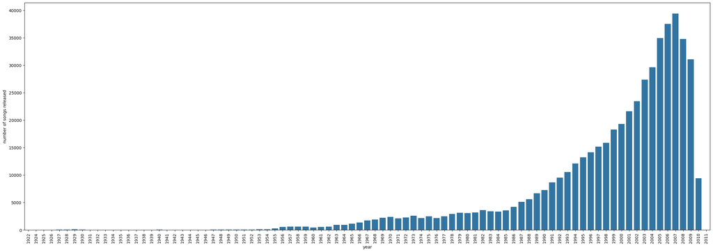

```python
plt.figure(figsize = (30,10))
ax = sns.barplot(x = count.index,
            y = 'title',
            data = count,
            estimator = np.median,)
for item in ax.get_xticklabels(): item.set_rotation(90)
plt.ylabel('number of songs released')
# Show the plot
plt.show()
```

#### **Extra Code Cell**

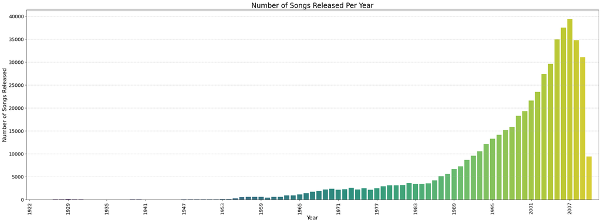

```python
import matplotlib.ticker as ticker

plt.figure(figsize = (30,10))
ax = sns.barplot(x = count.index,
            y = 'title',
            data = count,
            estimator = np.median,
            palette = 'viridis') # Added a color palette for visual appeal

# Set the maximum number of x-axis ticks for better readability
ax.xaxis.set_major_locator(ticker.MaxNLocator(nbins=15))
plt.tick_params(axis='x', labelsize=14)

# Set y-axis tick label size
plt.tick_params(axis='y', labelsize=14)

# Set the title and labels
plt.title('Number of Songs Released Per Year', fontsize=20)
plt.xlabel('Year', fontsize=16)
plt.ylabel('Number of Songs Released', fontsize=16)

for item in ax.get_xticklabels():
    item.set_rotation(90)

# Add grid for better readability
plt.grid(axis='y', linestyle='--', alpha=0.7)

# Show the plot
plt.show()
```

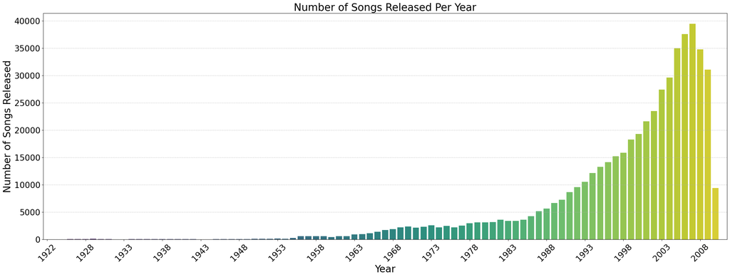

```python
import matplotlib.ticker as ticker

plt.figure(figsize = (30,10))
ax = sns.barplot(x = count.index,
            y = 'title',
            data = count,
            estimator = np.median,
            palette = 'viridis') # Added a color palette for visual appeal

# Set the maximum number of x-axis ticks for better readability
ax.xaxis.set_major_locator(ticker.MaxNLocator(nbins=19))
plt.tick_params(axis='x', labelsize=20)

# Set y-axis tick label size
plt.tick_params(axis='y', labelsize=20)

# Set the title and labels
plt.title('Number of Songs Released Per Year', fontsize=25)
plt.xlabel('Year', fontsize=24)
plt.ylabel('Number of Songs Released', fontsize=24)

for item in ax.get_xticklabels():
    item.set_rotation(45)

# Add grid for better readability
plt.grid(axis='y', linestyle='--', alpha=0.7)

# Show the plot
plt.show()
```

```python
# Define the bin edges for decades (including the last year present in the data)
decade_bins = [1919, 1929, 1939, 1949, 1959, 1969, 1979, 1989, 1999, 2009, 2011]

# Define labels for the decades
decade_labels = ['1920s', '1930s', '1940s', '1950s', '1960s', '1970s', '1980s', '1990s', '2000s', '2010s']

# Create a new DataFrame with years binned by decade
# Ensure 'year' is a column to use pd.cut
count_reset = count.reset_index()
count_reset['decade'] = pd.cut(count_reset['year'], bins=decade_bins, labels=decade_labels, right=True)

# Group by decade and sum the number of songs
decade_counts = count_reset.groupby('decade')['title'].sum().reset_index()

# Display the aggregated data
display(decade_counts.head())
```

|  | decade | title |
| --- | --- | --- |
| 0 | 1920s | 225 |
| 1 | 1930s | 252 |
| 2 | 1940s | 356 |
| 3 | 1950s | 3104 |
| 4 | 1960s | 11741 |

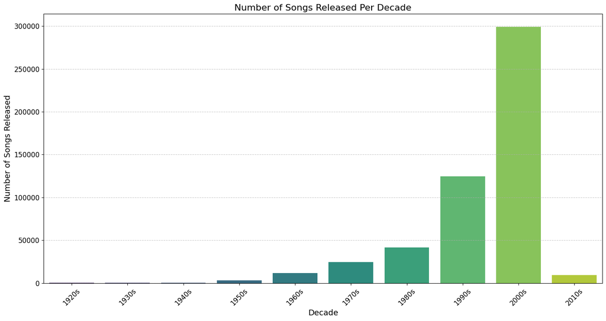

```python
import matplotlib.ticker as ticker

plt.figure(figsize = (15, 8))
ax = sns.barplot(x = 'decade',
            y = 'title',
            data = decade_counts,
            palette = 'viridis') # Added a color palette for visual appeal

# Set x-axis tick label size
plt.tick_params(axis='x', labelsize=12)

# Set y-axis tick label size
plt.tick_params(axis='y', labelsize=12)

# Set the title and labels
plt.title('Number of Songs Released Per Decade', fontsize=16)
plt.xlabel('Decade', fontsize=14)
plt.ylabel('Number of Songs Released', fontsize=14)

for item in ax.get_xticklabels():
    item.set_rotation(45)

# Add grid for better readability
plt.grid(axis='y', linestyle='--', alpha=0.7)

plt.tight_layout() # Adjust layout to prevent labels from being cut off

# Show the plot
plt.show()
```